# Protein filtering

Three rules decide which proteins and runs are fit to analyse, applied in this order: contaminants go by identity, outlier runs go by a consensus of four checks, and proteins go when too few of the remaining runs detected them. No rule reads abundance differences between groups.

## Packages

proteoDA holds the protein table, its annotation and the sample sheet together in one object, a `DAList`, and supplies the zero and detection filters used below. The project helpers supply `write_workbook()`, which writes every workbook with the same opening and closing sheets, and `permutation_p()`.

```r
library(here)
library(proteoDA)
library(dplyr)
library(tidyr)
library(tibble)
library(stringr)
library(purrr)
library(readr)
library(readxl)
library(ggplot2)
library(forcats)
source(here("00_Setup", "Shared_functions", "analysis_reporting_helpers.R"))
```

```r
out <- here("01_Processing", "01_Protein_Filtering", "c_data")
dir.create(out, recursive = TRUE, showWarnings = FALSE)
inputs <- c(
  report = "00_Setup/Input/HRvLR_raw.xlsx",
  samples = "00_Setup/Input/metadata.csv",
  blood = "01_Processing/01_Protein_Filtering/references/blood_contaminants.csv",
  hpa = "01_Processing/01_Protein_Filtering/references/HPA_annotations_full.tsv",
  rbc = "01_Processing/01_Protein_Filtering/references/RBC_proteome_reference.tsv"
)
paths <- map_chr(inputs, here)
stopifnot(file.exists(paths))

raw <- read_excel(paths[["report"]])
metadata <- read_csv(paths[["samples"]], show_col_types = FALSE) |>
  select(sample_id, subject, group, timepoint, group_time) |>
  as.data.frame()
rownames(metadata) <- metadata$sample_id

dim(raw)
```

```
[1] 2400   53
```

```r
head(metadata)
```

```
       sample_id subject group timepoint group_time
S03_T1    S03_T1  HR_S03    HR        T1      HR_T1
S10_T1    S10_T1  HR_S10    HR        T1      HR_T1
S16_T1    S16_T1  HR_S16    HR        T1      HR_T1
S22_T1    S22_T1  HR_S22    HR        T1      HR_T1
S24_T1    S24_T1  HR_S24    HR        T1      HR_T1
S27_T1    S27_T1  HR_S27    HR        T1      HR_T1
```

```r
count(metadata, group, timepoint)
```

```
  group timepoint n
1    HR        T1 8
2    HR        T2 8
3    HR        T3 8
4    LR        T1 8
5    LR        T2 8
6    LR        T3 8
```

Every run column must match a row of the sample sheet. A run missing from either side would drop out silently or come back all-NA, so the check stops the script.

```r
annotation_cols <- c("uniprot_id", "protein", "gene", "description", "n_seq")
runs <- setdiff(names(raw), annotation_cols)
stopifnot("sample sheet and report disagree" = setequal(runs, metadata$sample_id))
annotation <- raw[, annotation_cols]
intensity <- data.matrix(raw[, metadata$sample_id])
n_raw <- nrow(annotation)
intensity[1:3, 1:4]
```

```
      S03_T1  S10_T1  S16_T1  S22_T1
[1,]      NA      NA      NA      NA
[2,] 3455560 1310680 5467120 2731610
[3,]  232182  105692  319299      NA
```

## One row per accession

A UniProt accession can appear on more than one row when DIA-NN reports it in two protein groups. Each accession keeps its row with the highest mean intensity.

```r
duplicated_ids <- annotation$uniprot_id[duplicated(annotation$uniprot_id)]
keep_row <- tibble(
  i = seq_len(n_raw), id = annotation$uniprot_id, m = rowMeans(intensity, na.rm = TRUE)
) |>
  slice_max(m, n = 1, by = id, with_ties = FALSE) |>
  pull(i)
annotation <- annotation[keep_row, ]
intensity <- intensity[keep_row, ]
n_dedup <- length(keep_row)
c(raw = n_raw, kept = n_dedup, duplicated_accessions = length(unique(duplicated_ids)))
```

```
                  raw                  kept duplicated_accessions
                 2400                  2400                     0
```

## Blood index

A needle biopsy carries some blood, and the amount varies between biopsies. The blood index measures it: each run’s mean log2 intensity of the adult haemoglobin chains HBB and HBA1. Both chains are seen in all 48 runs. The gamma chain HBG2 was dropped from the index (decisions log, 2026-10-01): it was missing in 20 runs, the low-blood ones, so averaging whatever was present lifted exactly those runs by about 1.57 log2.

```r
log_int <- log2(intensity)
log_int[!is.finite(log_int)] <- NA
blood_anchor <- c("HBB", "HBA1")
anchors <- log_int[annotation$gene %in% blood_anchor, , drop = FALSE]
stopifnot(nrow(anchors) == length(blood_anchor), !anyNA(anchors))
blood_index <- colMeans(anchors)
summary(blood_index)
```

```
   Min. 1st Qu.  Median    Mean 3rd Qu.    Max.
  29.94   31.61   32.24   32.34   33.05   34.82
```

Two quantities follow from the index. `blood_rel` subtracts each run’s median log2 intensity, so a run loaded more heavily overall does not look bloodier; later steps carry it as a model covariate. `blood_cor` is each protein’s Spearman correlation with the index across runs, computed when at least 15 runs saw the protein. It is reported and removes nothing.

```r
testable <- rowSums(!is.na(log_int)) >= 15
blood_cor <- suppressWarnings(as.vector(cor(
  t(log_int), blood_index,
  method = "spearman", use = "pairwise.complete.obs"
)))
blood_cor[!testable] <- NA
blood_rel <- blood_index - apply(log_int, 2, median, na.rm = TRUE)
metadata$blood_rel <- unname(blood_rel[metadata$sample_id])
tibble(gene = annotation$gene, blood_cor) |>
  slice_max(blood_cor, n = 5)
```

```
# A tibble: 5 × 2
  gene   blood_cor
  <chr>      <dbl>
1 HBA1       0.973
2 HBB        0.966
3 SLC4A1     0.957
4 CAT        0.942
5 SNCA       0.936
```

## Contamination per run, before removal

Five marker panels show how much of each run’s summed intensity comes from skin (keratins), blood, white cells, fat and muscle fibre. These shares describe the runs and decide nothing.

```r
qc_panels <- list(
  keratin = c(
    "KRT1", "KRT2", "KRT10", "KRT8", "KRT9", "KRT16", "KRT14", "KRT5", "KRT6A", "KRT6B", "DCD"
  ),
  blood = c(
    "HBB", "HBA1", "HBD", "HBG1", "HBG2", "HBQ1", "AHSP", "ALB", "CA1", "SLC4A1", "SPTA1"
  ),
  leukocyte = c("MPO", "CTSG", "ELANE", "PRTN3", "AZU1", "S100A8", "S100A9", "LYZ", "LTF"),
  adipose = c("FABP4", "PLIN1", "PLIN4", "ADIPOQ", "ADIRF"),
  myofibre = c(
    "MB", "CKM", "ACTA1", "MYH1", "MYH2", "MYH7", "ALDOA", "CASQ1", "PYGM", "ATP2A1", "DES"
  )
)
qc_index <- imap(qc_panels, \(genes, panel) {
  tibble(
    sample_id = colnames(intensity), panel = panel,
    pct_signal = 100 * colSums(intensity[annotation$gene %in% genes, , drop = FALSE],
      na.rm = TRUE
    ) / colSums(intensity, na.rm = TRUE)
  )
}) |>
  list_rbind() |>
  left_join(select(metadata, sample_id, subject, group, timepoint), by = "sample_id")
```

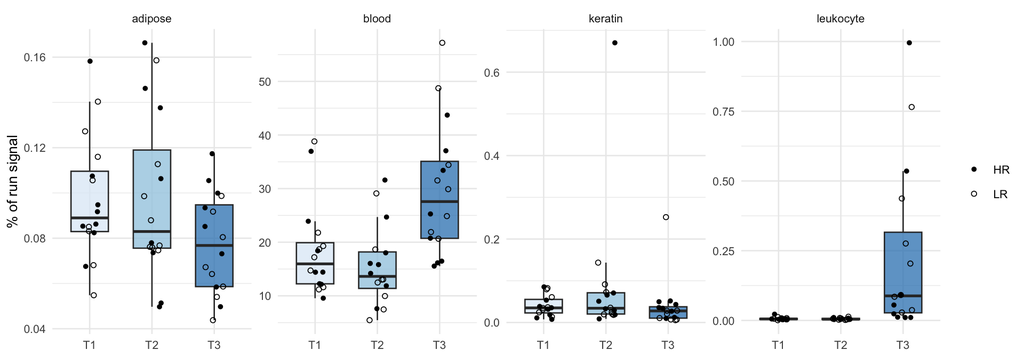

Figure 1: Each run’s signal share per contamination panel, before removal; filled HR, open LR.

```r
qc_index |>
  filter(panel != "myofibre") |>
  ggplot(aes(timepoint, pct_signal, fill = timepoint)) +
  geom_boxplot(outlier.shape = NA, width = 0.6, alpha = 0.75) +
  geom_point(aes(shape = group), position = position_jitter(width = 0.15, seed = 42), size = 1.4) +
  facet_wrap(~panel, scales = "free_y", nrow = 1) +
  scale_fill_brewer(palette = "Blues", guide = "none") +
  scale_shape_manual(values = c(HR = 16, LR = 1), name = NULL) +
  labs(x = NULL, y = "% of run signal") +
  theme_minimal(base_size = 10)
```

## Contaminants, by identity

A protein is removed for what it is, never for how it behaves in these runs. Two sources say what it is.

The curated list names 30 accessions in the code below (keratins and other skin proteins, globins, immunoglobulin constant regions, complement) and 95 more in `references/blood_contaminants.csv`, each with its class and reason (`references/README.md`). Matching is by accession only. Matching by gene symbol or description fails here: cRAP, the common Repository of Adventitious Proteins used to screen laboratory contaminants, lists ALDOA_RABIT, which collides with muscle ALDOA, and a trypsin or albumin pattern catches parvalbumin. Only cRAP’s dust-and-contact section is used, because its UPS1 standard section holds myoglobin and creatine kinase M, both muscle proteins.

```r
contaminants <- tribble(
  ~uniprot_id, ~gene, ~class, ~reason,
  "P04264", "KRT1", "keratin", "cRAP dust/contact; cornified epidermal",
  "P35908", "KRT2", "keratin", "cRAP dust/contact; epidermal",
  "P13645", "KRT10", "keratin", "cRAP dust/contact; type-I partner of KRT1",
  "P35527", "KRT9", "keratin", "cRAP dust/contact; palmoplantar",
  "P08779", "KRT16", "keratin", "cRAP dust/contact",
  "P04259", "KRT6B", "keratin", "cRAP dust/contact",
  "P02533", "KRT14", "keratin", "cRAP dust/contact; basal epidermal",
  "P13647", "KRT5", "keratin", "cRAP dust/contact; basal epidermal",
  "P02538", "KRT6A", "keratin", "cRAP dust/contact",
  "Q04695", "KRT17", "keratin", "cRAP dust/contact",
  "Q7Z794", "KRT77", "keratin", "cRAP dust/contact",
  "Q8N1N4", "KRT78", "keratin", "cRAP dust/contact",
  "P05787", "KRT8", "keratin", "simple-epithelial; Spearman +0.78 with the KRT1/2/10 load",
  "P15924", "DSP", "keratin", "desmoplakin; skin desmosome",
  "Q02413", "DSG1", "keratin", "desmoglein-1; skin desmosome",
  "P81605", "DCD", "keratin", "dermcidin; sweat",
  "P31151", "S100A7", "keratin", "psoriasin; skin",
  "P01040", "CSTA", "keratin", "cystatin-A; cornified envelope",
  "P68871", "HBB", "globin", "red-cell carryover",
  "P69905", "HBA1", "globin", "red-cell carryover",
  "P02042", "HBD", "globin", "red-cell carryover",
  "P69891", "HBG1", "globin", "red-cell carryover",
  "P69892", "HBG2", "globin", "orphan gamma-globin; shares tryptic peptides with HBB/HBD",
  "P09105", "HBQ1", "globin", "red-cell carryover",
  "Q9NZD4", "AHSP", "globin", "erythroid-specific haemoglobin chaperone",
  "P01834", "IGKC", "immunoglobulin", "absent from HPA; constant region",
  "P01860", "IGHG3", "immunoglobulin", "absent from HPA; constant region",
  "P01880", "IGHD", "immunoglobulin", "absent from HPA; constant region",
  "P02746", "C1QB", "complement", "absent from HPA",
  "P00736", "C1R", "complement", "absent from HPA"
) |>
  bind_rows(
    read_csv(paths[["blood"]], col_types = cols(.default = "c")) |>
      select(uniprot_id, gene, class, reason)
  )
count(contaminants, class)
```

```
# A tibble: 7 × 2
  class              n
  <chr>          <int>
1 complement        12
2 erythrocyte       19
3 globin             7
4 immunoglobulin    23
5 keratin           18
6 leukocyte          5
7 plasma            41
```

The Human Protein Atlas (HPA) tags proteins the list misses: secreted to blood (plasma), an immunoglobulin gene, or erythrocyte RNA at or above 5,000 nCPM (normalised transcripts per million in single-cell data). A blood-tagged protein is rescued as muscle when myonuclei express it at 20 nCPM or more and its plasma concentration is below 10^9 pg/L.

Evidence behind these cuts:

- `myo_cut` 20: at 50 the rescue missed GPI (43.1 nCPM), ANXA2 (40.2) and PPIA (21.1), all muscle proteins; the plasma-concentration cap, not this floor, separates plasma from muscle.
- `ery_cut` 5,000 and `blood_max` 10^9 pg/L: no recorded evidence. The V1 decisions log notes that mature red cells carry almost no RNA, so the erythrocyte RNA tag caught none of six known red-cell proteins there; the curated list carries that load instead.

Absence from HPA never removes a protein. Membership of the red-cell reference proteome (`in_rbc`, five published red-cell proteomes) is reported and removes nothing, because red cells share much of their proteome with muscle.

```r
strip_iso <- function(x) sub("-[0-9]+$", "", x)
hpa <- read_tsv(paths[["hpa"]], show_col_types = FALSE) |>
  transmute(
    acc = Uniprot, protein_class = `Protein class`, secretome = `Secretome location`,
    blood_conc = suppressWarnings(as.numeric(`Blood concentration - Conc. blood MS [pg/L]`)),
    ery = suppressWarnings(as.numeric(`Single Cell Type RNA - Erythrocytes [nCPM]`)),
    myo = suppressWarnings(as.numeric(`Single Cell Type RNA - Myonuclei [nCPM]`))
  ) |>
  filter(!is.na(acc), acc != "") |>
  separate_longer_delim(acc, delim = ", ") |>
  mutate(acc = strip_iso(acc)) |>
  distinct(acc, .keep_all = TRUE)
rbc <- read_tsv(paths[["rbc"]], show_col_types = FALSE)
c(hpa_accessions = nrow(hpa), rbc_reference = nrow(rbc))
```

```
hpa_accessions  rbc_reference
         19217           7012
```

Each protein gets one verdict. The curated list wins first; then a blood tag removes unless the muscle rescue applies.

```r
protein_calls <- annotation |>
  mutate(acc = strip_iso(uniprot_id), blood_cor = blood_cor) |>
  left_join(hpa, by = "acc") |>
  left_join(
    select(contaminants, acc = uniprot_id, contam_class = class, contam_reason = reason),
    by = "acc"
  ) |>
  mutate(
    is_curated = !is.na(contam_class),
    is_ery = !is.na(ery) & ery >= 5000,
    is_ig = str_detect(coalesce(protein_class, ""), "Immunoglobulin genes"),
    is_plasma = !is.na(secretome) & secretome == "Secreted to blood",
    in_rbc = acc %in% na.omit(rbc$acc) | gene %in% na.omit(rbc$gene),
    rescued = !is.na(myo) & myo >= 20 & (is.na(blood_conc) | blood_conc < 1e9),
    is_blood = is_ery | is_ig | is_plasma,
    contaminant = is_curated | (is_blood & !rescued),
    verdict = case_when(
      is_curated ~ paste0("remove: ", contam_class),
      is_blood & rescued ~ "keep: rescued (muscle-expressed)",
      is_plasma ~ "remove: plasma",
      is_ig ~ "remove: immunoglobulin",
      is_ery ~ "remove: erythrocyte",
      TRUE ~ "keep"
    ),
    reason = coalesce(contam_reason, verdict)
  ) |>
  select(
    uniprot_id, gene, description, verdict, reason, contaminant, in_rbc,
    secretome, blood_conc, ery, myo, blood_cor
  )
stopifnot(protein_calls$contaminant == str_starts(protein_calls$verdict, "remove"))
count(protein_calls, verdict)
```

```
# A tibble: 9 × 2
  verdict                              n
  <chr>                            <int>
1 keep                              2163
2 keep: rescued (muscle-expressed)    15
3 remove: complement                  12
4 remove: erythrocyte                 19
5 remove: globin                       7
6 remove: immunoglobulin              41
7 remove: keratin                     18
8 remove: leukocyte                    5
9 remove: plasma                     120
```

```r
protein_calls |>
  filter(str_detect(verdict, "rescued")) |>
  slice_max(myo, n = 5) |>
  select(gene, secretome, blood_conc, myo)
```

```
# A tibble: 5 × 4
  gene  secretome         blood_conc   myo
  <chr> <chr>                  <dbl> <dbl>
1 HMGB1 Secreted to blood    1500000 362.
2 TFRC  Secreted to blood  140000000 169.
3 ERAP1 Secreted to blood   34000000 135.
4 COPA  Secreted to blood     170000 102.
5 IL18  Secreted to blood      21000  64.2
```

The kept proteins enter a `DAList`. proteoDA’s own annotation filter is not used: its class check calls `if()` on a length-2 class vector and errors on every real `DAList` (package behaviour, seen in V1), so the subset is plain indexing. `zero_to_missing()` then turns DIA-NN’s zeros, which mean “not detected”, into `NA`.

```r
keep <- !protein_calls$contaminant
int_df <- as.data.frame(intensity[keep, ])
annot_df <- as.data.frame(annotation[keep, ])
rownames(int_df) <- rownames(annot_df) <- annot_df$uniprot_id
c(zeros_before = sum(int_df == 0, na.rm = TRUE), na_before = sum(is.na(int_df)))
```

```
zeros_before    na_before
           0        24343
```

```r
dal <- zero_to_missing(DAList(data = int_df, annotation = annot_df, metadata = metadata))
c(zeros_after = sum(dal$data == 0, na.rm = TRUE), na_after = sum(is.na(dal$data)))
```

```
zeros_after    na_after
          0       24343
```

## Outlier runs

Four checks each flag runs that sit far from the rest:

- missingness: a run’s share of missing values, or its gap from the same person’s other runs, beyond the Tukey fence (upper quartile + 1.5 × interquartile range);
- PCA distance: Mahalanobis distance on the first three principal components of the proteins seen in every run, beyond the chi-square 0.99 quantile;
- median intensity: more than 3 median absolute deviations (MAD) from the median run (the Hampel rule);
- correlation: a run’s median correlation with the other runs, more than 3 MAD below the median.

A run is removed when three of the four agree. Evidence (decisions log, 2026-10-06): kept, these runs lowered limpa’s detection-curve slope from 0.67 to 0.59, and limma’s sample weights did not single them out. The manuscript’s pipeline removes the same three runs by its own consensus.

```r
lg <- log2(dal$data + 1)
complete <- dal$data[rowSums(is.na(dal$data)) == 0, ]
pcs <- prcomp(t(log2(complete + 1)), center = TRUE, scale. = TRUE)$x[, 1:3]
med_cor <- apply(cor(lg, use = "pairwise.complete.obs"), 2, \(x) median(x[x < 1], na.rm = TRUE))
hampel <- function(x) abs(x - median(x)) > 3 * mad(x)
tukey <- function(x) x > quantile(x, 0.75) + 1.5 * IQR(x)

outlier_diag <- dal$metadata |>
  select(sample_id, subject, group, timepoint) |>
  mutate(
    pct_missing = colMeans(is.na(dal$data))[sample_id] * 100,
    delta_missing = ave(pct_missing, subject, FUN = \(x) pmax(x - min(x), max(x) - x)),
    miss_flag = tukey(pct_missing) | tukey(delta_missing),
    pca_flag = mahalanobis(pcs, colMeans(pcs), cov(pcs)) > qchisq(0.99, df = 3),
    mad_flag = hampel(apply(lg, 2, median, na.rm = TRUE)[sample_id]),
    cor_flag = med_cor[sample_id] < median(med_cor) - 3 * mad(med_cor),
    n_flags = miss_flag + pca_flag + mad_flag + cor_flag,
    consensus_outlier = n_flags >= 3
  )
stopifnot(identical(rownames(pcs), outlier_diag$sample_id))
outlier_ids <- outlier_diag$sample_id[outlier_diag$consensus_outlier]
outlier_diag |>
  filter(n_flags > 0) |>
  arrange(desc(n_flags)) |>
  select(sample_id, ends_with("_flag"), n_flags)
```

```
       sample_id miss_flag pca_flag mad_flag cor_flag n_flags
S29_T1    S29_T1      TRUE     TRUE     TRUE     TRUE       4
S28_T3    S28_T3      TRUE     TRUE     TRUE     TRUE       4
S28_T2    S28_T2      TRUE    FALSE     TRUE     TRUE       3
S17_T2    S17_T2     FALSE     TRUE    FALSE     TRUE       2
S24_T3    S24_T3     FALSE     TRUE    FALSE     TRUE       2
S03_T1    S03_T1     FALSE    FALSE    FALSE     TRUE       1
S22_T1    S22_T1     FALSE    FALSE    FALSE     TRUE       1
S28_T1    S28_T1      TRUE    FALSE    FALSE    FALSE       1
S17_T1    S17_T1     FALSE    FALSE    FALSE     TRUE       1
S10_T2    S10_T2      TRUE    FALSE    FALSE    FALSE       1
S14_T2    S14_T2     FALSE    FALSE    FALSE     TRUE       1
S10_T3    S10_T3     FALSE    FALSE    FALSE     TRUE       1
```

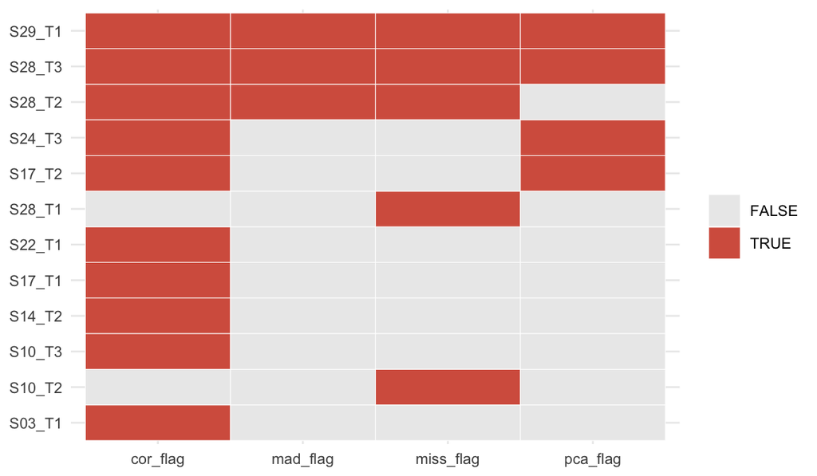

Figure 2: Runs flagged by at least one outlier check. Three or more flags remove a run.

```r
outlier_diag |>
  filter(n_flags > 0) |>
  pivot_longer(ends_with("_flag"), names_to = "method", values_to = "flagged") |>
  mutate(sample_id = fct_reorder(sample_id, n_flags)) |>
  ggplot(aes(method, sample_id, fill = flagged)) +
  geom_tile(colour = "white") +
  scale_fill_manual(values = c(`TRUE` = "#D6604D", `FALSE` = "grey92"), name = NULL) +
  labs(x = NULL, y = NULL) +
  theme_minimal(base_size = 10)
```

```r
dal <- filter_samples(dal, !(sample_id %in% outlier_ids))
c(runs_removed = length(outlier_ids), runs_kept = ncol(dal$data))
```

```
runs_removed    runs_kept
           3           45
```

## Detection filter

`filter_proteins_by_group()` (proteoDA) keeps a protein detected in at least `min_reps` runs of at least `min_groups` of the six group-by-time cells. Here a protein needs 5 detections in one cell. This is the one step in 01_Processing that reads the HR/LR label; it counts detections and never compares abundance. It runs after the outlier removal so that no discarded run counts toward a detection. The floor of 5, in cells of 7 or 8 runs, has no recorded evidence.

```r
n_before <- nrow(dal$data)
dal <- filter_proteins_by_group(dal, min_reps = 5, min_groups = 1, grouping_column = "group_time")
c(before = n_before, after = nrow(dal$data))
```

```
before  after
  2178   1900
```

## Blood by group at T3

If one group’s T3 biopsies carried more blood, the acute interaction contrasts would partly measure blood. A mixed model (group × timepoint, a random intercept per person, fitted with lme4) estimates the LR-minus-HR difference at T3 on two scales: the log2 blood index and the blood panel’s share of signal. The permutation p shuffles the group label across people 999 times and asks how often a shuffled t is at least as large as the observed one.

```r
blood_data <- dal$metadata |>
  select(sample_id, subject, group, timepoint) |>
  mutate(group = factor(group, c("HR", "LR")), log2_index = unname(blood_index[sample_id])) |>
  left_join(filter(qc_index, panel == "blood") |> select(sample_id, pct_signal), by = "sample_id")
group_by_t3 <- function(data, response) {
  fit <- suppressMessages(lme4::lmer(
    reformulate(c("group * timepoint", "(1 | subject)"), response),
    data = data
  ))
  coef(summary(fit))["groupLR:timepointT3", c("Estimate", "t value")]
}
set.seed(42)
groups <- distinct(blood_data, subject, group)
blood_by_group <- map(set_names(c("log2_index", "pct_signal")), \(response) {
  observed <- group_by_t3(blood_data, response)
  null_t <- replicate(999, {
    shuffled <- set_names(sample(groups$group), groups$subject)
    group_by_t3(mutate(blood_data, group = shuffled[subject]), response)[["t value"]]
  })
  tibble(
    scale = response, lr_minus_hr_at_t3 = round(observed[["Estimate"]], 3),
    t = round(observed[["t value"]], 2),
    permutation_p = permutation_p(abs(observed[["t value"]]), abs(null_t))
  )
}) |>
  list_rbind()
blood_by_group
```

```
# A tibble: 2 × 4
  scale      lr_minus_hr_at_t3     t permutation_p
  <chr>                  <dbl> <dbl>         <dbl>
1 log2_index             0.842  1.37         0.233
2 pct_signal             7.85   1.15         0.356
```

## Why no single blood_cor cut

How large a chance correlation with the blood index can be depends on how many runs saw the protein. Shuffling the index 300 times and taking the 99.9th percentile of |rho| by observation count shows that no single cut serves every protein, which is why `blood_cor` removes nothing.

```r
set.seed(42)
tested <- log_int[testable, ]
blood_null_rho <- replicate(300, abs(as.vector(suppressWarnings(cor(
  t(tested), sample(blood_index),
  method = "spearman", use = "pairwise.complete.obs"
)))))
n_obs <- cut(rowSums(!is.na(tested)), c(0, 25, 40, Inf), c("15-25", "26-40", "41-48"))
null_999 <- \(rows) round(quantile(blood_null_rho[rows, ], 0.999, na.rm = TRUE, names = FALSE), 3)
blood_null <- bind_rows(
  map(levels(n_obs), \(bin) {
    tibble(observations = bin, proteins = sum(n_obs == bin), null_999 = null_999(n_obs == bin))
  }),
  tibble(observations = "all", proteins = length(n_obs), null_999 = null_999(TRUE))
)
blood_null
```

```
# A tibble: 4 × 3
  observations proteins null_999
  <chr>           <int>    <dbl>
1 15-25             234    0.712
2 26-40             488    0.561
3 41-48            1368    0.474
4 all              2090    0.593
```

## Validation

The filtered object must hold only kept proteins and runs, with the sample sheet still aligned to the data columns and no contaminant left.

```r
stopifnot(
  identical(colnames(dal$data), dal$metadata$sample_id),
  identical(rownames(dal$data), dal$annotation$uniprot_id),
  !any(rownames(dal$data) %in% protein_calls$uniprot_id[protein_calls$contaminant]),
  !any(colnames(dal$data) %in% outlier_ids),
  !anyNA(dal$metadata$blood_rel)
)
```

## Summary

```r
removed <- count(filter(protein_calls, contaminant), verdict, name = "n_removed")
filter_log <- tibble(
  step = c("raw input", "duplicate accession", removed$verdict, "outlier samples", "detection"),
  n_removed = c(NA, n_raw - n_dedup, removed$n_removed, 0L, n_before - nrow(dal$data))
) |>
  mutate(
    n_after = n_raw - cumsum(coalesce(n_removed, 0L)),
    pct_of_raw = round(100 * n_after / n_raw, 1),
    n_samples = c(rep(nrow(metadata), nrow(removed) + 2), rep(ncol(dal$data), 2))
  )
filter_log
```

```
# A tibble: 11 × 5
   step                   n_removed n_after pct_of_raw n_samples
   <chr>                      <int>   <int>      <dbl>     <int>
 1 raw input                     NA    2400      100          48
 2 duplicate accession            0    2400      100          48
 3 remove: complement            12    2388       99.5        48
 4 remove: erythrocyte           19    2369       98.7        48
 5 remove: globin                 7    2362       98.4        48
 6 remove: immunoglobulin        41    2321       96.7        48
 7 remove: keratin               18    2303       96          48
 8 remove: leukocyte              5    2298       95.8        48
 9 remove: plasma               120    2178       90.8        48
10 outlier samples                0    2178       90.8        45
11 detection                    278    1900       79.2        45
```

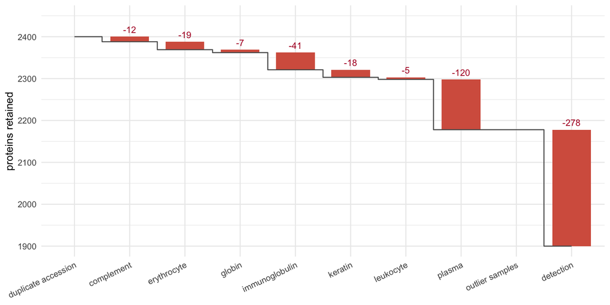

Figure 3: Proteins removed at each filtering step, and the number left after it.

```r
filter_log |>
  filter(!is.na(n_removed)) |>
  mutate(step = fct_inorder(str_remove(step, "^remove: ")), ymax = n_after + n_removed) |>
  ggplot(aes(step)) +
  geom_rect(aes(
    xmin = as.numeric(step) - 0.35, xmax = as.numeric(step) + 0.35, ymin = n_after, ymax = ymax
  ), fill = "#D6604D") +
  geom_step(aes(y = n_after, group = 1), direction = "mid", colour = "grey35") +
  geom_text(aes(y = ymax, label = if_else(n_removed > 0, paste0("-", n_removed), "")),
    vjust = -0.6, size = 3, colour = "#B2182B"
  ) +
  scale_y_continuous(expand = expansion(mult = c(0.05, 0.15))) +
  labs(x = NULL, y = "proteins retained") +
  theme_minimal(base_size = 10) +
  theme(axis.text.x = element_text(angle = 25, hjust = 1))
```

2400 proteins were measured in 48 runs. 222 went as contaminants and 278 by the detection filter, leaving 1900 proteins. 3 runs (S29_T1, S28_T2, S28_T3) failed three or more outlier checks, leaving 45.

## Save

`DAList_filtered.rds` is the input to normalisation. The workbook keeps every table above; `05_Figures/Processing/S01_QC` reads it.

```r
saveRDS(dal, file.path(out, "DAList_filtered.rds"), compress = "xz")
sheets <- list(
  filter_log = filter_log,
  contaminants_removed = arrange(filter(protein_calls, contaminant), verdict, gene),
  rescued = arrange(filter(protein_calls, str_detect(verdict, "rescued")), desc(myo)),
  protein_calls = protein_calls,
  contamination_index = qc_index,
  blood_index = tibble(
    sample_id = names(blood_index), blood_index = unname(blood_index),
    blood_rel = unname(blood_rel)
  ),
  outlier_diagnostics = outlier_diag,
  blood_by_group = blood_by_group,
  blood_cor_null = blood_null
)
holds <- c(
  "Proteins left after each step.",
  "Every protein removed as a contaminant, with its verdict and reason.",
  "Blood-tagged proteins kept by the muscle rescue.",
  "One verdict per protein, with the annotation behind it.",
  "Share of each sample's signal per contamination panel, before removal.",
  "Mean log2 haemoglobin per sample, raw and relative to the sample's median log2 intensity.",
  "The four outlier flags per sample.",
  "Group by T3 blood term on two scales, with a permutation p.",
  "99.9th percentile of the blood_cor permutation null, by observation count."
)
write_workbook(sheets, holds, file.path(out, "protein_filtering.xlsx"), inputs, paths)
```